# Medidas de tendencia central

[Sebastian Castellanos López](https://A0166.github.io)

Taller IV 2022-2, [Facultad de economía](http://www.economia.unam.mx/)

2/3/2022

### 1. ¿Qué son las medidas de tendencia central? 🤔

> “Antes que nada, definamos brevemente a qué hacen referencia las medidas de tendencia central. Las medidas de tendencia central son parámetros estadísticos que informan sobre el centro de distribución de la muestra o la población estadística. En otras palabras, es un número que se ubica hacia el centro de la distribución de los valores de una serie de observaciones o medidas, en la que se encuentra localizado el conjunto de los datos.”

[crehana (2022)](https://www.crehana.com/ar/blog/data-analitica/medidas-de-tendencia-central/)

Para este ejemplo, primero generaremos una serie de **100** números aleatorios entre **1** y **20** mediante la función `sample`. El argumento `TRUE` nos permitirá generar una muestra con remplazo:

```r
numeros <- sample(1:20, 100, TRUE)
numeros
```

```
##   [1]  3  6  1 11  6 18  2  3 19 14  9 19  2  4 20  2  9  3  3  8  2 19 10  9 11
##  [26] 14 13 18  2 17 11  3 10 10 19 14 17 14 18  5 14 15 15  9 13  6  7 14  3 18
##  [51] 10  2  5 15 16  1 12 16 11  7  9  7 11  2 11  5 12 16 16  6 13 16 10 15 17
##  [76]  4  7  8 11 14 12 12  8  8 10 10 12  7 16 20  8 18 10 19  4 18 12 13 19 20
```

### 2. Mediana 📍

> “La siguiente medida de tendencia central es la mediana. Para calcular la mediana, lo que se debe hacer es”partir en dos” la muestra. Para hacer esto, es necesario agrupar los datos de menor valor a mayor valor, dejando la misma cantidad de valores de un lado que del otro.

> Es diferente a la media ya que nos da la posición promedio del conjunto de datos.”

[crehana (2022)](https://www.crehana.com/ar/blog/data-analitica/medidas-de-tendencia-central/)

Para obtener la **mediana**, podemos ordenar los `numeros` de menor a mayor, **el número que esté en medio de la muestra será la mediana**. Si utilizamos R, se puede hacer el cálculo de la **mediana** con la función `median`:

```r
mediana <- median(numeros)
mediana
```

```
## [1] 11
```

### 3. Media 🧮

> “La media es la medida de tendencia central más utilizada. Es el valor promedio de un conjunto de datos numéricos. Se calcula sumando el total del conjunto de valores dividido entre el número total de valores, es decir, el tamaño de la muestra.”

[crehana (2022)](https://www.crehana.com/ar/blog/data-analitica/medidas-de-tendencia-central/)

$$Media ={\frac {1}{n}}\sum
_{i=1}^{n}a_{i}={\frac {a_{1}+a_{2}+\cdots +a_{n}}{n}}$$

Si usamos R, podemos obtener la media de una muestra si utlilizamos la función **mean**:

```r
media <- mean(numeros)
media
```

```
## [1] 10.73
```

### 4. Moda 📊

> “Finalmente, llegamos a la moda. Esta medida de tendencia central es sencillamente el valor que más se repite en la muestra estadística o población. No existe una fórmula matemática.”

[crehana (2022)](https://www.crehana.com/ar/blog/data-analitica/medidas-de-tendencia-central/)

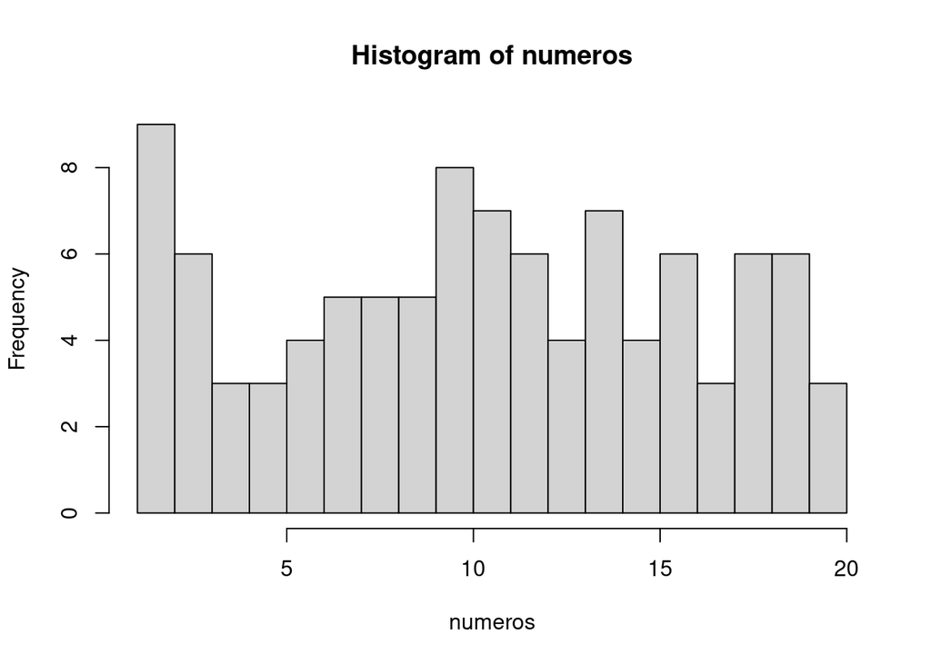

```r
# El argumento breaks nos permite dividir en histograma en las partes que queramos
hist(numeros, breaks = 20)
```

Para obtener un resultado con más precisión, podemos obtener la **moda** si generamos una **tabla de frecuencias** con la función `table` y la función `data.frame`, **aquel elemento con mayor frecuencia será la moda**:

```r
tabla.frecuencias <- data.frame(table(numeros))
tabla.frecuencias
```

```
##    numeros Freq
## 1        1    2
## 2        2    7
## 3        3    6
## 4        4    3
## 5        5    3
## 6        6    4
## 7        7    5
## 8        8    5
## 9        9    5
## 10      10    8
## 11      11    7
## 12      12    6
## 13      13    4
## 14      14    7
## 15      15    4
## 16      16    6
## 17      17    3
## 18      18    6
## 19      19    6
## 20      20    3
```

### 5. Ejercicio 👩‍💻👨‍💻✍

Aplica lo que aprendiste, obten la **mediana**, **media** y **moda** de la siguiente muestra de números:

```r
# Con la función seq, creamos una secuencia de 1 a 10 en intervalos de 0.1 en 0.1
secuencia <- seq(1, 10, 0.1)
muestra <- sample(secuencia, 100, TRUE)
muestra
```

```
##   [1]  5.9  7.9  5.2  6.1  2.8  6.7  9.4  9.5  8.3  8.1  5.0  7.0 10.0  9.1  4.4
##  [16]  9.6  3.7  8.6  4.2  1.3  5.3  3.0  9.8  6.4  4.4  8.6  6.0  3.3  4.4  4.1
##  [31]  6.7  7.6  1.4  1.3  8.8  5.7  3.0  1.6  9.6  8.0  8.1  2.6  5.9  3.7  9.5
##  [46]  7.5  4.2  1.4 10.0  8.9  2.5  8.3  3.0  9.4  4.3  5.1  8.3  4.0  2.2  9.9
##  [61]  2.3  7.5  1.8  1.3  8.3  7.7  8.7  1.7  9.7  8.3  7.8  9.2  8.1  5.3  9.5
##  [76]  3.1  7.5  5.6  8.0  4.5  5.6  6.6  2.7  1.7  6.0  5.9  2.8  9.2  5.8  9.8
##  [91]  9.2  3.5  3.5  2.1  4.0  2.5  2.7  2.2  2.1  3.0
```

##### Mediana

```r
# Aquí el cálculo de la mediana
mediana.2 <- median(muestra)
mediana.2
```

```
## [1] 5.85
```

##### Media

```r
# Aquí el cálculo de la media
media.2 <- mean(muestra)
media.2
```

```
## [1] 5.774
```

##### Moda

```r
# Aquí el cálculo de la moda
tabla.moda.2 <- data.frame(table(muestra))
tabla.moda.2
```

```
##    muestra Freq
## 1      1.3    3
## 2      1.4    2
## 3      1.6    1
## 4      1.7    2
## 5      1.8    1
## 6      2.1    2
## 7      2.2    2
## 8      2.3    1
## 9      2.5    2
## 10     2.6    1
## 11     2.7    2
## 12     2.8    2
## 13       3    4
## 14     3.1    1
```

[output cut: 44 more lines]

💻[Código disponible en RStudio Cloud](https://rstudio.cloud/project/3671022)💻